# Exploring Inflation, Income, and Wealth

Ratul Esrar

December 11, 2017

```
## [1] TRUE
```

### Graph 1: Does Consumer Price Index Tell the Whole Story?

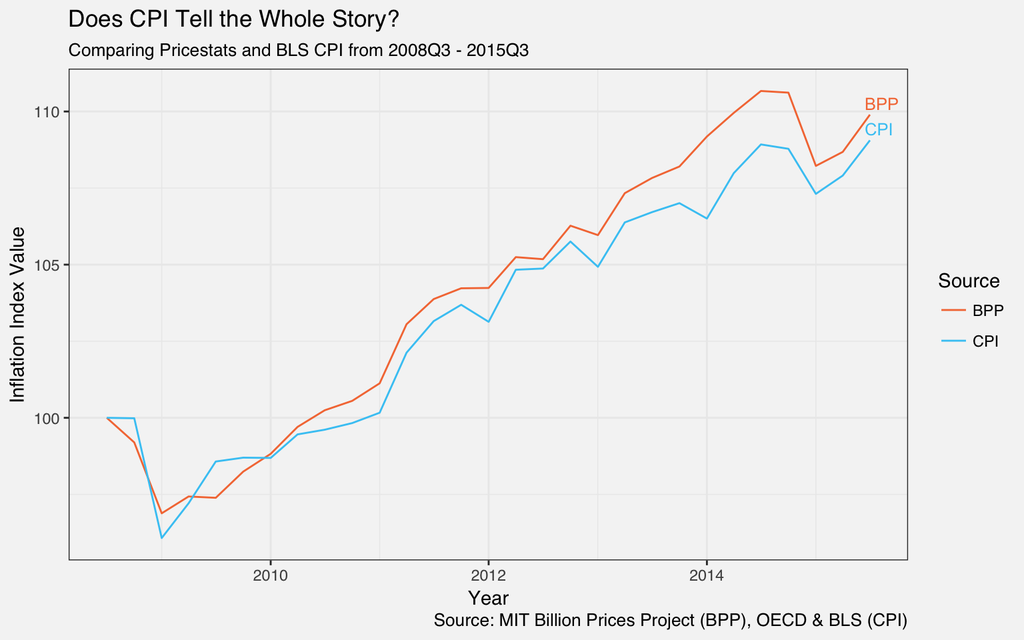

The Bureau of Labor Statistics (BLS) reports a measure of inflation called Consumer Price Index (CPI) each quarter. CPI expresses the current prices of a basket of goods and services relative to the prices of those same goods and services in a previous year to show the effect of inflation on purchasing power. However, CPI may not be the best measure of inflation. Using daily consumer price index calculations calculated by the Pricestats database from MIT’s Billion Prices Project is arguably a more precise measure of inflation than quarterly reports by the BLS. Looking at quarterly CPI reports relative to the Pricestats index shows an interesting relationship, especially during times of recession. The Pricestats CPI is generally higher than the BLS report except during recession periods.

### Graph 2: Perhaps the BLS Exercises More Discretion During Recessions

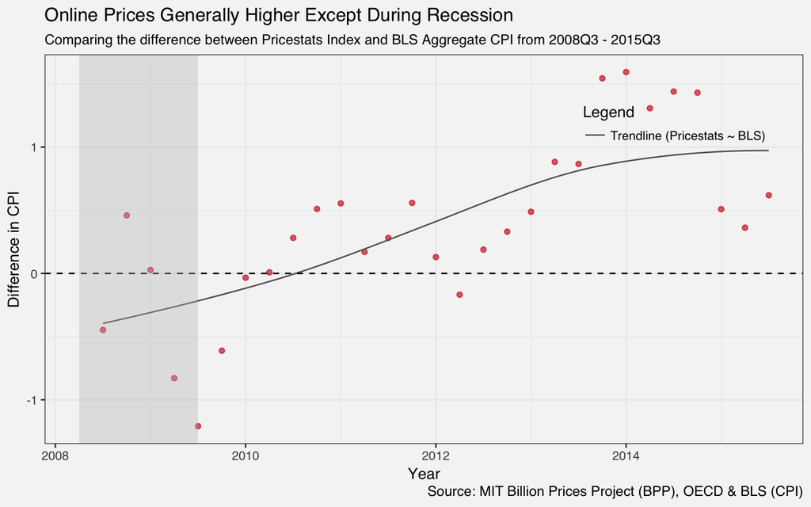

Looking more closely at the differences between the OECD’s reported CPI, which is taken from the BLS, and the Pricestats Index of online prices, we see two interesting things. First, the CPI is trending upward and that makes sense as the United States has not been in a period of deflation since 2008Q3. Second, the difference between the Pricestats Index and CPI is negative during the 2008 recession but has been positive in almost every period since then. It is possible that the BLS exercised more discretion in reporting CPI during periods of economic stagnation to artificially indicate economic growth.

### Graph 3: Despite the Great Recession, Housing Prices Rose Faster than CPI

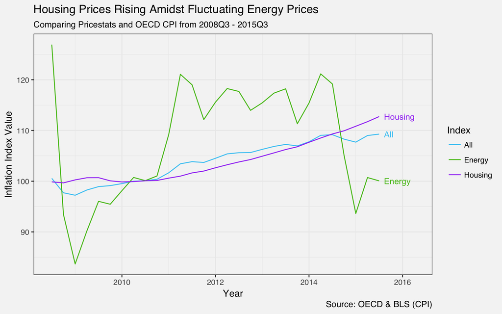

What happens when we look at other price indexes broken down by housing and energy, two services everyone uses? It looks as though major fluctuations in energy prices may skew the aggregate CPI, since housing prices have been rising steadily, yet the aggregate follows the troughs in energy prices.

### Graph 4: Changes in Average Personal Income Outpaced Change in Inflation

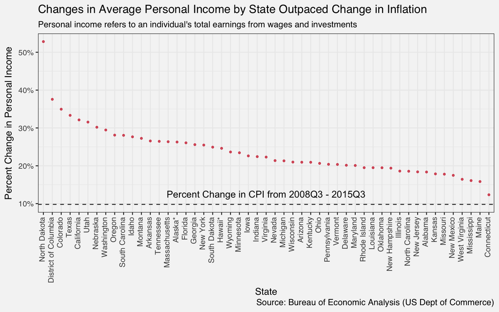

When examining difference in CPI over time, it is also prudent to look at changes to income, or in this case, aggregate personal income by state (seasonally adjusted), which encompasses a person’s total earnings and investments. Between 2008 and 2015, the median change in total personal income by state was around 23 percent, while the CPI only increased by 10 percent in the same period of time. It’s possible that total personal income is skewed due to the top earners in each state, which may be why that change seems much larger than the change in inflation. There are also geographic factors to consider.

### Graph 5: Breaking Down Net Family Income by Percentile Tells a Another Story

[figure not shown]

### Graph 6: Family Income at the 10th Percentile Decreased While Prices of Goods Increased from 2009 to 2014

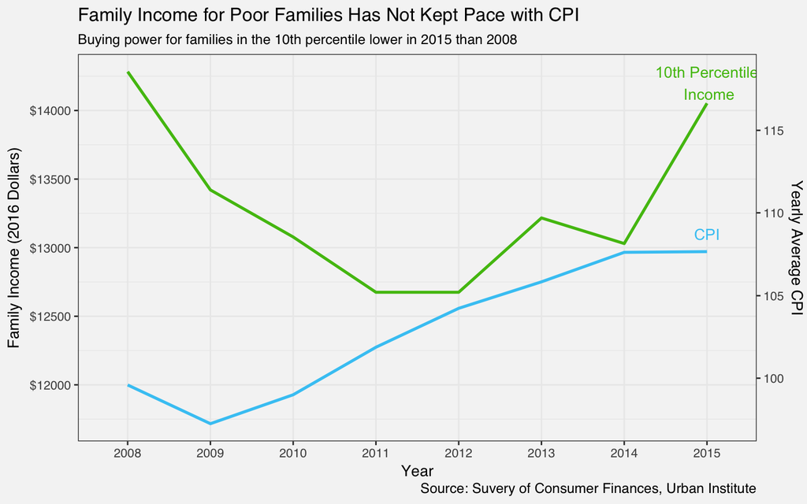

Taking a closer look, we can see that the 10th percentile family income decreased steadily from 2008 to 2012, but overall, the 2015 level was lower than that 2008 level. At the same time, CPI steadily increased until plateauing in 2014.

### Graph 7: Median Income is Highest in Northeastern States

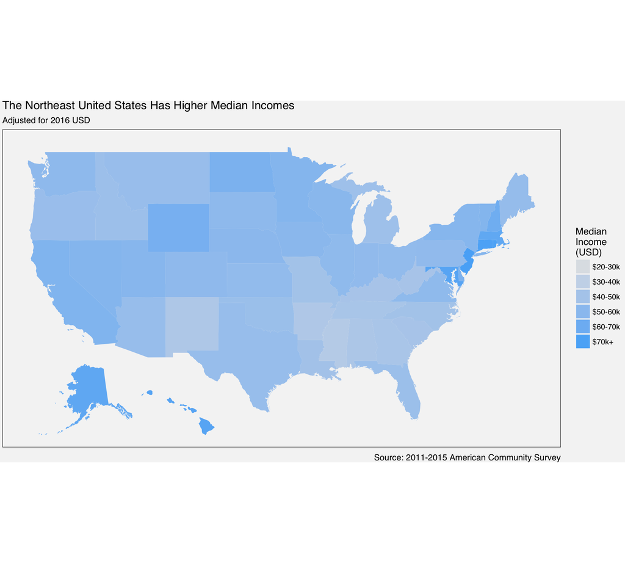

### Graph 8: Percent of Population in Poverty Varies but Easier to See in Rural Regions

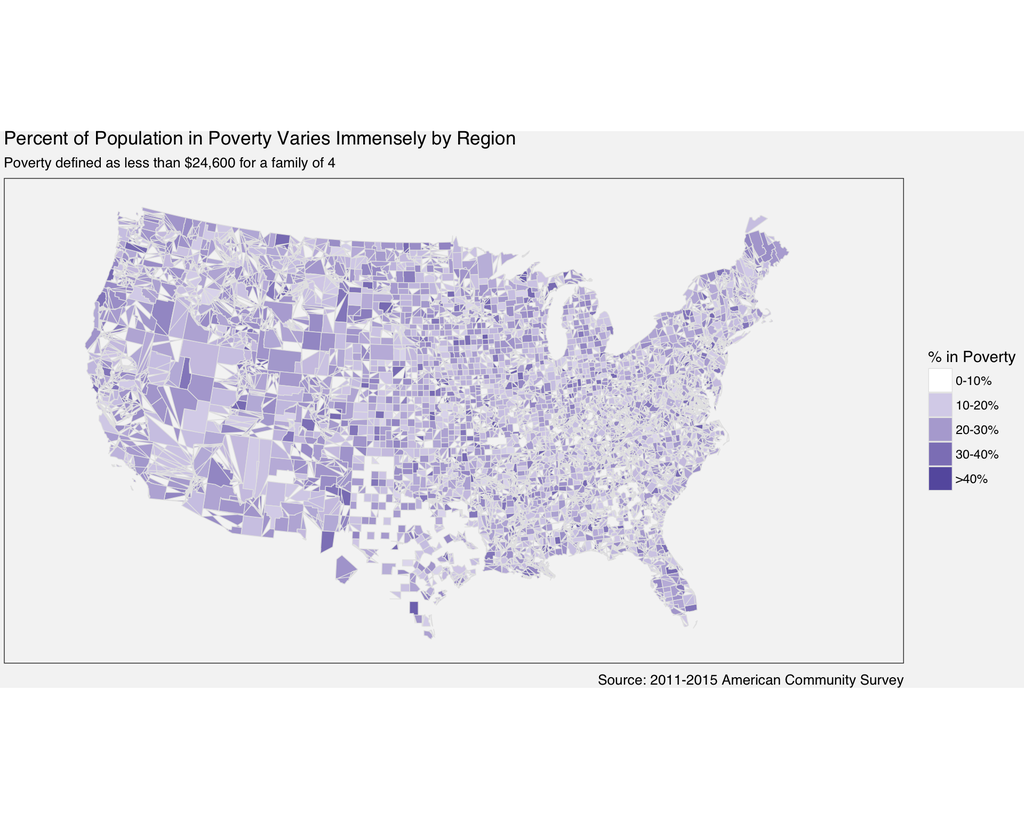

### Data Sources (Order of Appearence)

- Cavallo, Alberto, and Roberto Rigobon (2016), “The Billion Prices Project: Using Online Data for Measurement and Research” - Journal of Economic Perspectives , 31(1) (Spring 2016), doi:10.7910/DVN/6RQCRS, Harvard Dataverse, V2
- OECD (2017), Inflation (CPI) (indicator). doi:10.1787/eee82e6e-en (Accessed on 11 December 2017)
- U.S. Bureau of Economic Analysis, “Relation of Gross Domestic Product, Gross National Product, Net National Product, National Income, and Personal Income,” https://www.bea.gov/iTable/iTable.cfm?reqid=19&step=2# (Accessed on 11 December 2017)
- Smith, Karen, Urban Institute’s tabulations from the Current Population Survey 1963–2017, http://apps.urban.org/features/wealth-inequality-charts/data/IncomeDistribution.xlsx, (Accessed on 11 December 2017)
- U.S. Census Bureau; 2015 ACS 1-year and 2011-2015 ACS 5-year Data Releases